# Turismo mensual por CC.AA.

Leonardo Hansa

10/07/2022

Sinceramente, esto es una excusa para probar `arrow`. He encontrado en `datos.gob.es` un CSV con cierto tamaño así que he aprovechado. La fuente, [aquí.](https://datos.gob.es/es/catalogo/ea0010587-numero-de-turistas-pernoctaciones-y-duracion-media-por-ccaa-de-destino-desglosados-por-continente-y-pais-de-residencia-identificador-api-52046)

```r
library(dplyr)
library(arrow)
library(ggplot2)
```

## Datos

Quería probar `feather` o `parquet`. He hecho unas pruebas en algún código por ahí y me he decantado por `feather`: he priorizado tiempo sobre espacio. Porque sí.

```r
df_turismo_mes <- read_feather(
  sprintf("../data/%s.feather", params$caso),
  as_data_frame = FALSE
) %>%
  filter(
    concepto_turistico != "Turistas",
    continente_y_pais_de_residencia_nivel_1 == "Total",
    is.na(continente_y_pais_de_residencia_nivel_2),
    is.na(continente_y_pais_de_residencia_nivel_3),
    is.na(continente_y_pais_de_residencia_nivel_4)
  ) %>%
  select(destino, periodo, concepto_turistico, total) %>%
  mutate(periodo = as.Date(paste0(periodo, "01"), format = "%YM%m%d")) %>%
  group_by(destino, periodo, concepto_turistico) %>%
  summarise(total = sum(total, na.rm = TRUE), .groups = "drop") %>%
  collect()
```

### Algo de contexto

- Los datos son mensuales, de 2019-07-01 a 2022-05-01.
- Aparte de las CCAA, están las Ciudades Autónomas y el `Total Nacional`.
- Primero empiezo con `Pernoctaciones`, pero quizá luego me anime con `Duración media de los viajes`.

## Pernoctaciones

Las únicas CCAA con niveles de pernoctaciones previos a Covid son Madrid y Canarias (Madrid, no, realmente… pero casi, así que hago zoom luego).

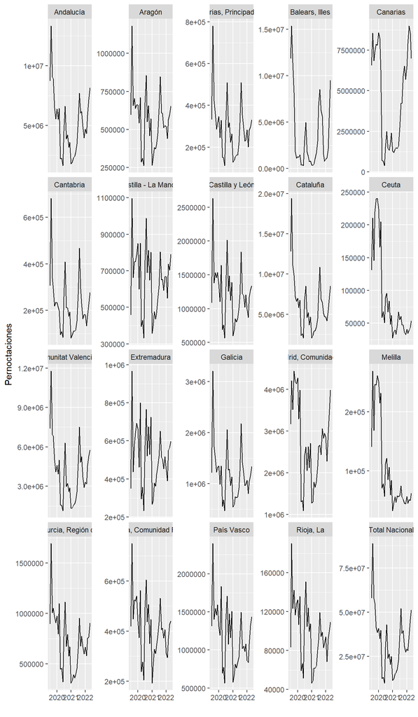

```r
df_turismo_mes %>%
  filter(concepto_turistico == "Pernoctaciones") %>%
  select(-concepto_turistico) %>%
  ggplot() +
  geom_line(aes(x = periodo, y = total)) +
  facet_wrap(~ destino, scales = "free_y") +
  labs(x = "", y = "Pernoctaciones")
```

### Madrid

Total de pernoctaciones en Madrid según continente de origen:

```r
calcula_pernoctaciones_por_origen <- function(.destino) {
  read_feather(
    sprintf("../data/%s.feather", params$caso),
    as_data_frame = FALSE
  ) %>%
    filter(
      concepto_turistico == "Pernoctaciones",
      destino == .destino
    ) %>%
    filter(
      !is.na(continente_y_pais_de_residencia_nivel_2),
      is.na(continente_y_pais_de_residencia_nivel_3),
      is.na(continente_y_pais_de_residencia_nivel_4)
    ) %>%
    mutate(
      periodo = as.Date(paste0(periodo, "01"), format = "%YM%m%d")
    ) %>%
    group_by(origen = continente_y_pais_de_residencia_nivel_2, periodo) %>%
    summarise(pernoctaciones = sum(total, na.rm = TRUE), .groups = "drop") %>%
    collect()
}

df_pernoc_madrid <- calcula_pernoctaciones_por_origen("Madrid, Comunidad de")

head(df_pernoc_madrid)
```

```
## # A tibble: 6 x 3
##   origen periodo    pernoctaciones
##   <chr>  <date>              <dbl>
## 1 Europa 2022-05-01        2942923
## 2 Europa 2022-04-01        2676592
## 3 Europa 2022-03-01        2252285
## 4 Europa 2022-02-01        1797024
## 5 Europa 2022-01-01        2116918
## 6 Europa 2021-12-01        2307671
```

```r
df_pernoc_madrid %>%
  filter(origen != "Total") %>%
  group_by(origen) %>%
  summarise(pernoctaciones = sum(pernoctaciones)) %>%
  mutate(pct_pernoc = pernoctaciones / sum(pernoctaciones),
         pct_pernoc = scales::percent(pct_pernoc, decimal.mark = ",")) %>%
  arrange(desc(pernoctaciones)) %>%
  knitr::kable(col.names = c("Origen", "Pernoctaciones", "%"), format.args = list(big.mark = "."))
```

| Origen | Pernoctaciones | % |
| --- | --- | --- |
| Europa | 75.133.214 | 78,6% |
| América | 14.152.276 | 14,8% |
| Asia | 4.319.519 | 4,5% |
| África | 1.802.297 | 1,9% |
| Oceanía | 139.919 | 0,1% |

```r
# ggplot(aes(x = reorder(origen, pernoctaciones), y = pernoctaciones)) +
# geom_col() +
# geom_label(aes(label  = pct_pernoc)) +
# labs(x = "", y = "Pernoctaciones") +
# coord_flip()
```

Los europeos y americanos están ahí, dándolo todo:

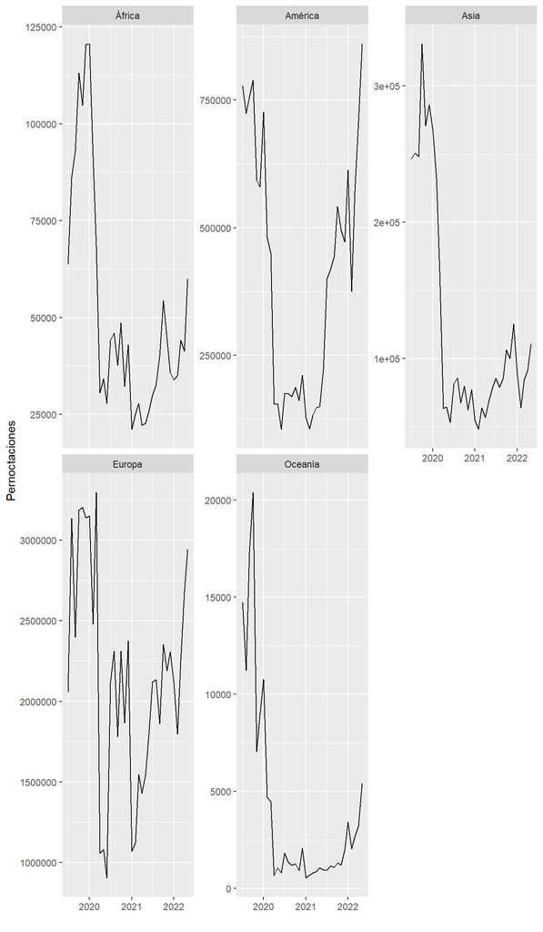

```r
ggplot(df_pernoc_madrid) +
  geom_line(aes(x = periodo, y = pernoctaciones)) +
  facet_wrap(~origen, scales = "free_y") +
  labs(x = "", y = "Pernoctaciones")
```

### Canarias

Total de pernoctaciones en Canarias según continente de origen:

```r
df_pernoc_canarias <- calcula_pernoctaciones_por_origen("Canarias")

head(df_pernoc_canarias)
```

```
## # A tibble: 6 x 3
##   origen periodo    pernoctaciones
##   <chr>  <date>              <dbl>
## 1 Europa 2022-05-01        6839054
## 2 Europa 2022-04-01        8371761
## 3 Europa 2022-03-01        8824378
## 4 Europa 2022-02-01        7730102
## 5 Europa 2022-01-01        6349568
## 6 Europa 2021-12-01        5553109
```

```r
df_pernoc_canarias %>%
  filter(origen != "Total") %>%
  group_by(origen) %>%
  summarise(pernoctaciones = sum(pernoctaciones)) %>%
  mutate(pct_pernoc = pernoctaciones / sum(pernoctaciones),
         pct_pernoc = scales::percent(pct_pernoc, decimal.mark = ",")) %>%
  arrange(desc(pernoctaciones)) %>%
  knitr::kable(
    col.names = c("Origen", "Pernoctaciones", "%"),
    format.args = list(big.mark = ".")
  )
```

| Origen | Pernoctaciones | % |
| --- | --- | --- |
| Europa | 153.350.113 | 97,449% |
| América | 1.657.538 | 1,053% |
| África | 1.233.316 | 0,784% |
| Asia | 1.092.023 | 0,694% |
| Oceanía | 31.351 | 0,020% |

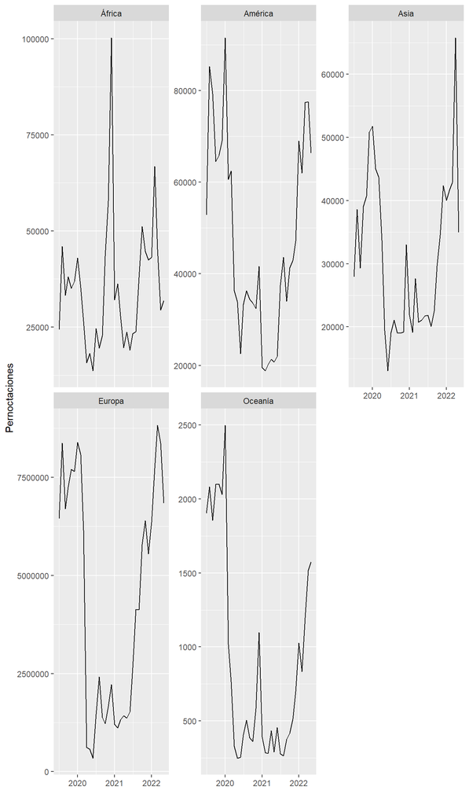

```r
ggplot(df_pernoc_canarias) +
  geom_line(aes(x = periodo, y = pernoctaciones)) +
  facet_wrap(~origen, scales = "free_y") +
  labs(x = "", y = "Pernoctaciones")
```